# Biostatistics III in R

Code by Mark Clements

# Exercise 14. Non-collapsibility of proportional hazards models

We simulate for time-to-event data assuming *constant hazards* and then investigate whether we can estimate the underlying parameters. Note that the binary variable $X$ is essentially a coin toss and we have used a large variance for the normally distributed $U$.

You may have to install the required packages the first time you use them. You can install a package by `install.packages("package_of_interest")` for each package you require.

```r
library(biostat3)
library(rstpm2)
library(ggplot2)
```

The assumed causal diagram is reproduced below:

[figure not shown]

```r
set.seed(12345)
d <- local({
    n <- 1e4
    x <- rbinom(n, 1, 0.5)
    u <- rnorm(n, 0, 3)
    t <- rexp(n, exp(-5+x+u))
    c <- runif(n, 0, 10)
    y <- pmin(t, c)
    delta <- (t < c)
    data.frame(y,x,u,delta)
})
head(d)
```

## (a) Fitting models with both $X$ and $U$

For constant hazards, we can fit (i) Poisson regression, (ii) Cox regression and (iii) flexible parametric survival models.

```r
summary(fit1 <- glm(delta~x+u+offset(log(y)),data=d,family=poisson))

summary(fit2 <- coxph(Surv(y,delta)~x+u,data=d))

summary(fit3 <- stpm2(Surv(y,delta)~x+u,data=d,df=4))

## summary table for the coefficients for X
rbind(Poisson=coef(summary(fit1))["x",c("Estimate","Std. Error")],
      Cox=coef(summary(fit2))["x",c("coef","se(coef)")],
      Stpm2=coef(summary(fit3))["x",c("Estimate","Std. Error")])
```

[output not shown]

It may be useful to investigate whether the hazard ratio for $X$ is time-varying hazard ratio and the form for survival.

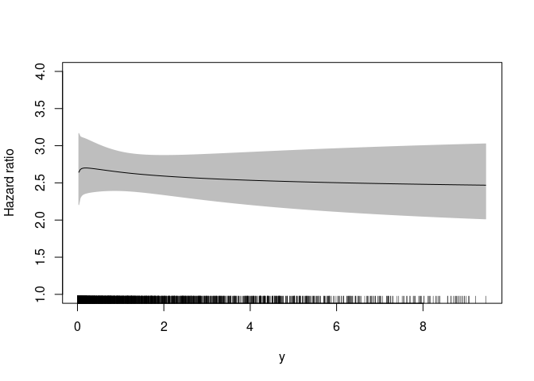

```r
fit <- stpm2(Surv(y,delta)~x+u,data=d,df=4, tvc=list(x=2))
plot(fit, type="hr", newdata=data.frame(x=0,u=0), var="x", ylim=c(1,4))
```

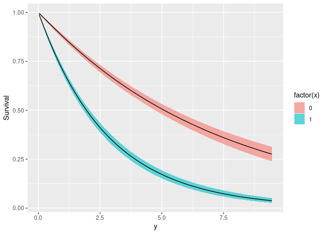

```r
s <- predict(fit, type="surv", newdata=data.frame(x=0:1,u=3), grid=TRUE, full=TRUE,
             se.fit=TRUE)

ggplot(s, aes(x=y,y=Estimate,fill=factor(x),ymin=lower,ymax=upper)) +
    ylab("Survival") +
    geom_ribbon(alpha=0.6) +
    geom_line()
```

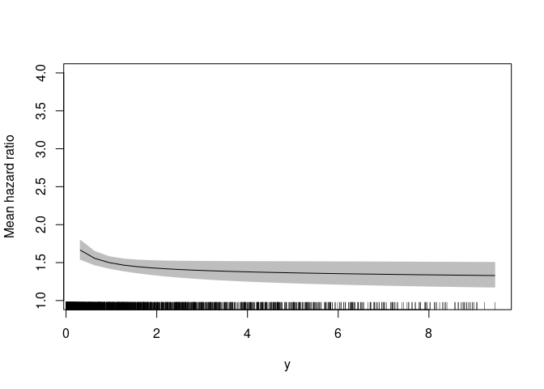

```r
plot(fit, type="meanhr", newdata=transform(d,x=0), var="x", seqLength=31, ylim=c(1,4))
```

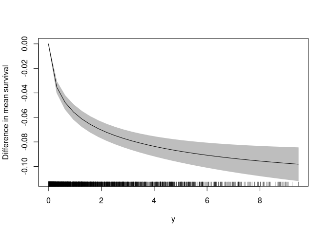

```r
plot(fit, type="meansurvdiff", newdata=transform(d,x=0), var="x", seqLength=31)
```

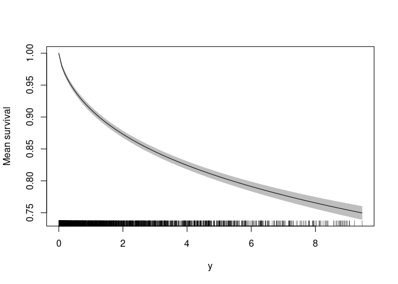

```r
plot(fit, type="meansurv", newdata=transform(d,x=0), seqLength=101)
```

## (b) Fitting models with only $X$

We now model by excluding the variable $U$. This variable could be excluded when it is not measured or perhaps when the variable is not considered to be a confounding variable – from the causal diagram, the two variables $X$ and $U$ are not correlated and are only connected through the time variable $T$.

```r
summary(fit1 <- glm(delta~x+offset(log(y)),data=d,family=poisson))

summary(fit2 <- coxph(Surv(y,delta)~x,data=d))

summary(fit3 <- stpm2(Surv(y,delta)~x,data=d,df=4))
```

```r
## summary table for the coefficients for X
rbind(Poisson=coef(summary(fit1))["x",c("Estimate","Std. Error")],
      Cox=coef(summary(fit2))["x",c("coef","se(coef)")],
      Stpm2=coef(summary(fit3))["x",c("Estimate","Std. Error")])
```

[output not shown]

Again, we suggest investigating whether the hazard ratio for $X$ is time-varying.

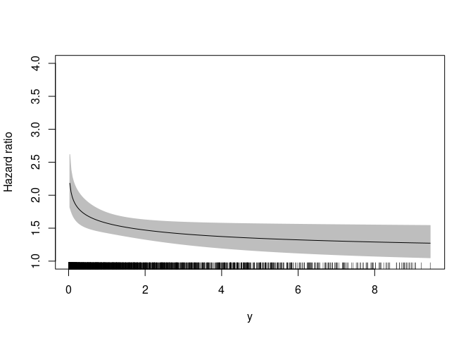

```r
fit <- stpm2(Surv(y,delta)~x,data=d,df=4, tvc=list(x=2))
plot(fit, type="hr", newdata=data.frame(x=0), var="x", ylim=c(1,4))
```

What do you see from the time-varing hazard ratio? Is $U$ a potential confounder for $X$?

## (c) Rarer outcomes

We now simulate for rarer outcomes by changing the censoring distribution:

```r
set.seed(12345)
d <- local({
    n <- 1e4*10 # CHANGED N
    x <- rbinom(n, 1, 0.5)
    u <- rnorm(n, 0, 3)
    t <- rexp(n, exp(-5+x+u))
    c <- runif(n, 0, 10/1000) # CHANGED FROM 10 TO 0.01
    y <- pmin(t, c)
    delta <- (t < c)
    data.frame(y,x,u,delta)
})
```

```r
summary(fit1 <- glm(delta~x+offset(log(y)),data=d,family=poisson))

summary(fit2 <- coxph(Surv(y,delta)~x,data=d))

summary(fit3 <- stpm2(Surv(y,delta)~x,data=d,df=4))
```

```r
## summary table for the coefficients for X
rbind(Poisson=coef(summary(fit1))["x",c("Estimate","Std. Error")],
      Cox=coef(summary(fit2))["x",c("coef","se(coef)")],
      Stpm2=coef(summary(fit3))["x",c("Estimate","Std. Error")])
```

```
##         Estimate Std. Error
## Poisson 1.081150  0.1212037
## Cox     1.081513  0.1212136
## Stpm2   1.081399  0.1212136
```

What do you observe?

## (d) Less heterogeneity

We now simulate for less heterogeneity by changing the reducing the standard deviation for the random effect $U$ from 3 to 1.

```r
set.seed(12345)
d <- local( {
    n <- 1e4
    x <- rbinom(n, 1, 0.5)
    u <- rnorm(n, 0, 1) # CHANGED SD FROM 3 TO 1
    t <- rexp(n, exp(-5+x+u))
    c <- runif(n, 0, 10)
    y <- pmin(t, c)
    delta <- (t < c)
    data.frame(y,x,u,delta)
})
```

```r
summary(fit1 <- glm(delta~x+offset(log(y)),data=d,family=poisson))

summary(fit2 <- coxph(Surv(y,delta)~x,data=d))

summary(fit3 <- stpm2(Surv(y,delta)~x,data=d,df=4))
```

```r
## summary table for the coefficients for X
rbind(Poisson=coef(summary(fit1))["x",c("Estimate","Std. Error")],
      Cox=coef(summary(fit2))["x",c("coef","se(coef)")],
      Stpm2=coef(summary(fit3))["x",c("Estimate","Std. Error")])
```

```
##          Estimate Std. Error
## Poisson 0.9498227 0.07583196
## Cox     0.9444216 0.07584759
## Stpm2   0.9441747 0.07584672
```

What do you observe?

## (e) Accelerated failure time models

As an alternative model class, we can fit *accelerated failure time models* with a smooth baseline survival function. We can use the *rstpm2::aft* function, which uses splines to model baseline survival. Using the baseline simulation, fit and interpret smooth accelerated failure time models:

```r
fit <- aft(Surv(y,delta)~x+u,data=d,df=4)
summary(fit)
```

```
## Maximum likelihood estimation
##
## Call:
## bbmle::mle2(minuslogl = negll, start = coef, eval.only = TRUE,
##     vecpar = TRUE, gr = gradient, control = control)
##
## Coefficients:
##                                        Estimate Std. Error  z value  Pr(z)
## x                                     -1.036381   0.087589 -11.8324 <2e-16 ***
## u                                     -0.993865   0.048413 -20.5289 <2e-16 ***
## nsx(logtstar, df, intercept = TRUE)1  -3.424935   0.362341  -9.4523 <2e-16 ***
## nsx(logtstar, df, intercept = TRUE)2   0.285719   0.263517   1.0843 0.2783
## nsx(logtstar, df, intercept = TRUE)3 -14.160032   0.770291 -18.3827 <2e-16 ***
## nsx(logtstar, df, intercept = TRUE)4   4.529814   0.488246   9.2777 <2e-16 ***
## ---
## Signif. codes:  0 '***' 0.001 '**' 0.01 '*' 0.05 '.' 0.1 ' ' 1
##
## -2 log L: 7681.266
```

```r
fit <- aft(Surv(y,delta)~x,data=d,df=4)
summary(fit)
```

```
## Maximum likelihood estimation
##
## Call:
## bbmle::mle2(minuslogl = negll, start = coef, eval.only = TRUE,
##     vecpar = TRUE, gr = gradient, control = control)
##
## Coefficients:
##                                        Estimate Std. Error  z value   Pr(z)
## x                                     -1.094700   0.094337 -11.6042 < 2e-16 ***
## nsx(logtstar, df, intercept = TRUE)1  -3.076847   0.303330 -10.1436 < 2e-16 ***
## nsx(logtstar, df, intercept = TRUE)2   0.577282   0.226405   2.5498 0.01078 *
## nsx(logtstar, df, intercept = TRUE)3 -13.490435   0.660353 -20.4291 < 2e-16 ***
## nsx(logtstar, df, intercept = TRUE)4   4.657197   0.419495  11.1019 < 2e-16 ***
## ---
## Signif. codes:  0 '***' 0.001 '**' 0.01 '*' 0.05 '.' 0.1 ' ' 1
##
## -2 log L: 8334.838
```